# Tape-Experiment — Snowmelt NEWGRIP

Schwarztape auf den Stäben 16–24 (= Knoten 6/7/8)

Author

Thom Laepple

Published

July 7, 2026

Am Kopf **IMEI 300434065508020** wurden die **Sensor-Stäbe 16–24** mit schwarzem Tape umwickelt. Jeder Knoten hat drei Stäbe (NTC1/NTC2/NTC3), **jeder NTC in einem eigenen Rohr** — d. h. Stäbe 16–18 → Knoten 6, 19–21 → Knoten 7, 22–24 → Knoten 8. Getapt sind also **alle drei Rohre der Knoten 6, 7 und 8**; das Tape sitzt sichtbar **inhomogen**. Es war von **2026-07-02 22:00** bis **2026-07-06 00:00** UTC angebracht und wurde dann wieder **entfernt** — ein An–Aus-Reversal. Zwei Fragen:

1. **Was macht das Tape** mit der gemessenen Temperatur?
2. **NTC2-Hypothese**: NTC2 sieht einen größeren *Rohr*-Anteil (`f`) gegenüber Luft als NTC1/NTC3 (der ~5 %-Feldeffekt). Wenn das Tape das Rohr heizt, die Luft aber nicht, sollte NTC2 minimal **mehr** vom Tape sehen: `d = NTC2 − Mittel(NTC1,NTC3) ≈ Δf · Heizung`.

Referenzquelle: die neueste Decoder-Zeitreihe `data/series_imei<IMEI>_*.csv`.

```r
IMEI        <- "300434065508020"
TAPED_NODES <- c(6, 7, 8)                 # = Stäbe 16–24 (3 Stäbe/Knoten)
NEIGHBORS   <- c(3, 4, 5, 9, 10, 11)      # blanke Nachbarn, gleiche Höhe (beide Seiten)
TAPE_START  <- "2026-07-02 22:00"         # UTC — Tape angebracht
TAPE_END    <- "2026-07-06 00:00"          # UTC — Tape wieder entfernt (Reversal)
SITE_LAT    <- 72.58                       # GRIP
SITE_LON    <- -37.64
SERIES_CSV  <- tail(sort(Sys.glob(sprintf("data/series_imei%s_*.csv", IMEI))), 1)
```

```r
library(dplyr); library(tidyr); library(ggplot2); library(patchwork)
stopifnot(length(SERIES_CSV) == 1L && file.exists(SERIES_CSV))
tape_start <- as.POSIXct(TAPE_START, tz = "UTC")
tape_end   <- as.POSIXct(TAPE_END,   tz = "UTC")

# Näherung Sonnenhöhe (Grad), ohne Paket.
solar_elev <- function(t, lat = SITE_LAT, lon = SITE_LON) {
  doy  <- as.numeric(format(t, "%j", tz = "UTC"))
  hh   <- as.numeric(format(t, "%H", tz = "UTC")) + as.numeric(format(t, "%M", tz = "UTC")) / 60
  decl <- 23.45 * sin(2 * pi * (284 + doy) / 365) * pi / 180
  H    <- ((hh + lon / 15) - 12) * 15 * pi / 180
  latr <- lat * pi / 180
  asin(sin(latr) * sin(decl) + cos(latr) * cos(decl) * cos(H)) * 180 / pi
}
```

```r
w <- read.csv(SERIES_CSV, stringsAsFactors = FALSE) |>
  mutate(time = as.POSIXct(time, tz = "UTC")) |>
  select(node, time, sensor, temp_C) |>
  pivot_wider(names_from = sensor, values_from = temp_C) |>
  mutate(elev  = solar_elev(time),
         phase = factor(case_when(time <  tape_start ~ "vor",
                                  time <  tape_end   ~ "getapt",
                                  TRUE               ~ "ab Tape"),
                        levels = c("vor", "getapt", "ab Tape")))

# Umgebungsreferenz je Zeit = Median NTC1 aller Knoten (6/7/8 sind nur 3 von 24).
ref <- w |> group_by(time) |> summarise(refT = median(ntc1_C, na.rm = TRUE), .groups = "drop")
w <- w |> left_join(ref, by = "time") |>
  mutate(anom = ntc1_C - refT,                          # Erwärmung ggü. Umgebung
         heiz = (ntc1_C + ntc2_C + testSB_C) / 3 - refT, # Knoten-Heizung (alle Kanäle)
         d    = ntc2_C - (ntc1_C + testSB_C) / 2,        # NTC2-Excess
         grp  = case_when(node %in% TAPED_NODES ~ "getapt (6/7/8)",
                          node %in% NEIGHBORS   ~ "blank (Nachbarn)",
                          TRUE ~ "andere"))
n_msg <- dplyr::n_distinct(w$time)
```

Datei `series_imei300434065508020_20260707_061557.csv` — 46 Messungen, 06-29 18:16–07-07 06:15 UTC.

## 1 · Was macht das Tape?

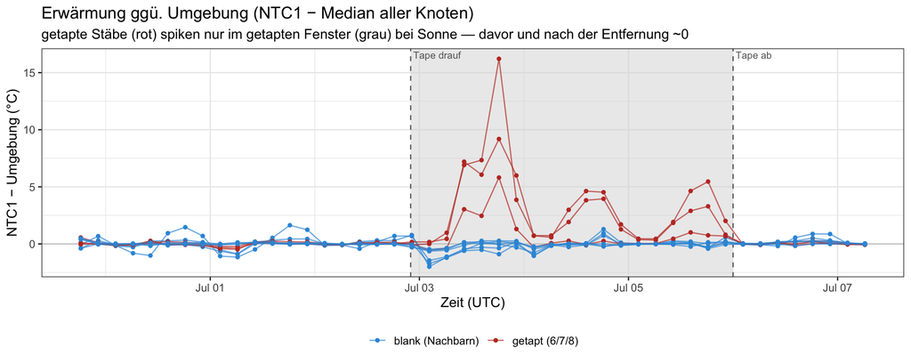

Figure 1

```r
pl <- w |> filter(grp != "andere")
ggplot(pl, aes(time, anom, group = node)) +
  annotate("rect", xmin = tape_start, xmax = tape_end, ymin = -Inf, ymax = Inf,
           fill = "grey85", alpha = 0.5) +
  geom_vline(xintercept = c(tape_start, tape_end), linetype = "dashed", colour = "grey40") +
  annotate("text", x = tape_start, y = Inf, label = " Tape drauf", hjust = 0, vjust = 1.4,
           size = 3, colour = "grey40") +
  annotate("text", x = tape_end, y = Inf, label = " Tape ab", hjust = 0, vjust = 1.4,
           size = 3, colour = "grey40") +
  geom_hline(yintercept = 0, colour = "grey80") +
  geom_line(aes(colour = grp), alpha = 0.7) +
  geom_point(aes(colour = grp), size = 1.2) +
  scale_colour_manual(values = c("getapt (6/7/8)" = "#c0392b", "blank (Nachbarn)" = "#3498db"),
                      name = NULL) +
  labs(title = "Erwärmung ggü. Umgebung (NTC1 − Median aller Knoten)",
       subtitle = "getapte Stäbe (rot) spiken nur im getapten Fenster (grau) bei Sonne — davor und nach der Entfernung ~0",
       x = "Zeit (UTC)", y = "NTC1 − Umgebung (°C)") +
  theme_bw(base_size = 12) + theme(legend.position = "bottom")
```

```r
sol_tab <- w |> filter(grp != "andere", elev > 25) |>
  group_by(node, grp, phase) |>
  summarise(anom = mean(anom, na.rm = TRUE), .groups = "drop") |>
  pivot_wider(names_from = phase, values_from = anom) |>
  arrange(grp, node)
knitr::kable(sol_tab, digits = 2,
             caption = "Solar-Anomalie (NTC1 − Umgebung) bei hoher Sonne (>25°) je Knoten und Phase")
```

Solar-Anomalie (NTC1 − Umgebung) bei hoher Sonne (>25°) je Knoten und Phase

| node | grp | vor | getapt | ab Tape |
| --- | --- | --- | --- | --- |
| 3 | blank (Nachbarn) | 0.22 | 0.09 | 0.32 |
| 4 | blank (Nachbarn) | 0.01 | -0.17 | 0.08 |
| 5 | blank (Nachbarn) | 0.35 | -0.02 | 0.41 |
| 9 | blank (Nachbarn) | 0.08 | 0.03 | -0.07 |
| 10 | blank (Nachbarn) | 0.04 | -0.03 | 0.21 |
| 11 | blank (Nachbarn) | 0.06 | -0.01 | 0.19 |
| 6 | getapt (6/7/8) | 0.06 | 5.18 | 0.01 |
| 7 | getapt (6/7/8) | 0.03 | 1.55 | 0.08 |
| 8 | getapt (6/7/8) | 0.19 | 5.35 | 0.20 |

```r
tap <- sol_tab |> filter(grp == "getapt (6/7/8)")
cat(sprintf("Getapte Stäbe (Knoten 6/7/8), Solar-Anomalie bei hoher Sonne — **vor %+.2f…%+.2f °C**, **getapt %+.1f…%+.1f °C**, **ab Tape %+.2f…%+.2f °C**. Spitze Knoten 8: NTC1 = +14.7 °C bei 07-03 18:15 (Luft ~−1.5 °C). Das Signal erscheint nur im getapten Fenster und verschwindet nach der Entfernung.\n",
            min(tap$vor), max(tap$vor), min(tap$getapt), max(tap$getapt),
            min(tap$`ab Tape`), max(tap$`ab Tape`)))
```

Getapte Stäbe (Knoten 6/7/8), Solar-Anomalie bei hoher Sonne — **vor +0.03…+0.19 °C**, **getapt +1.6…+5.4 °C**, **ab Tape +0.01…+0.20 °C**. Spitze Knoten 8: NTC1 = +14.7 °C bei 07-03 18:15 (Luft ~−1.5 °C). Das Signal erscheint nur im getapten Fenster und verschwindet nach der Entfernung.

## 2 · Sieht NTC2 mehr vom Tape? (Rohr- vs. Luftanteil)

Modell: jeder Sensor liest `f·T_Rohr + (1−f)·T_Luft`; das Tape hebt `T_Rohr`, nicht `T_Luft`. Größeres `f` bei NTC2 ⇒ `d = NTC2 − Mittel(NTC1,NTC3) ≈ Δf · Heizung` sollte **positiv mit der Heizung steigen**.

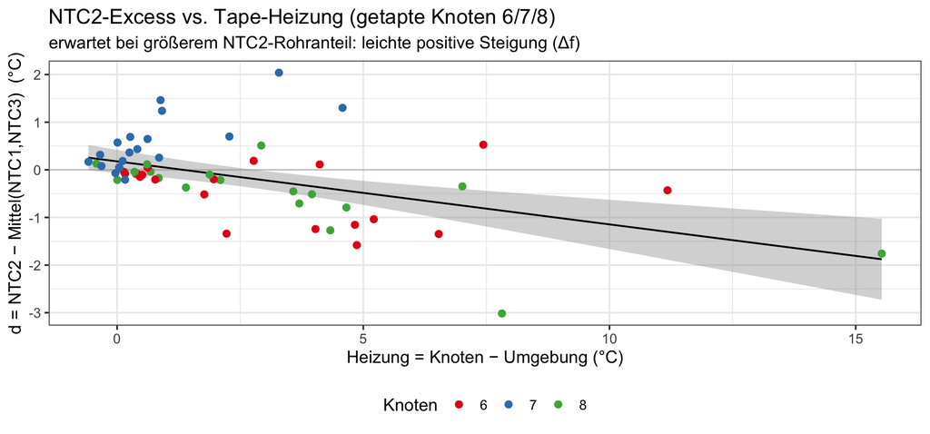

Figure 2

```r
tp <- w |> filter(node %in% TAPED_NODES, phase == "getapt")   # nur das getapte Fenster
fit  <- lm(d ~ heiz, tp)
ggplot(tp, aes(heiz, d, colour = factor(node))) +
  geom_hline(yintercept = 0, colour = "grey80") +
  geom_smooth(aes(group = 1), method = "lm", se = TRUE, colour = "black", linewidth = 0.6) +
  geom_point(size = 2) +
  scale_colour_brewer(palette = "Set1", name = "Knoten") +
  labs(title = "NTC2-Excess vs. Tape-Heizung (getapte Knoten 6/7/8)",
       subtitle = "erwartet bei größerem NTC2-Rohranteil: leichte positive Steigung (Δf)",
       x = "Heizung = Knoten − Umgebung (°C)", y = "d = NTC2 − Mittel(NTC1,NTC3)  (°C)") +
  theme_bw(base_size = 12) + theme(legend.position = "bottom")
```

```r
s      <- summary(fit)
slope  <- coef(fit)[["heiz"]]; pval <- s$coefficients["heiz", "Pr(>|t|)"]
hot    <- tp |> filter(heiz > 3)
d_hot  <- mean(hot$d, na.rm = TRUE); sd_hot <- sd(hot$d, na.rm = TRUE)
p_hot  <- tryCatch(t.test(hot$d)$p.value, error = function(e) NA)
cat(sprintf("Regression d ~ Heizung: Steigung **%+.3f** (≈ Δf), p = %.3f, n = %d. Stark geheizte Punkte (Heizung > 3 °C, n = %d): d = **%+.2f ± %.2f °C**, t-Test p = %.2f. Erwartet wäre Δf·Heizung ≈ 0.3–0.7 °C.\n",
            slope, pval, nrow(tp), nrow(hot), d_hot, sd_hot, p_hot))
```

Regression d ~ Heizung: Steigung **-0.132** (≈ Δf), p = 0.000, n = 57. Stark geheizte Punkte (Heizung > 3 °C, n = 18): d = **-0.65 ± 1.15 °C**, t-Test p = 0.03. Erwartet wäre Δf·Heizung ≈ 0.3–0.7 °C.